# Media Tone Analysis: ABC News Coverage of U.S. Elections

## 4.2 Pre-Election Theme Analysis

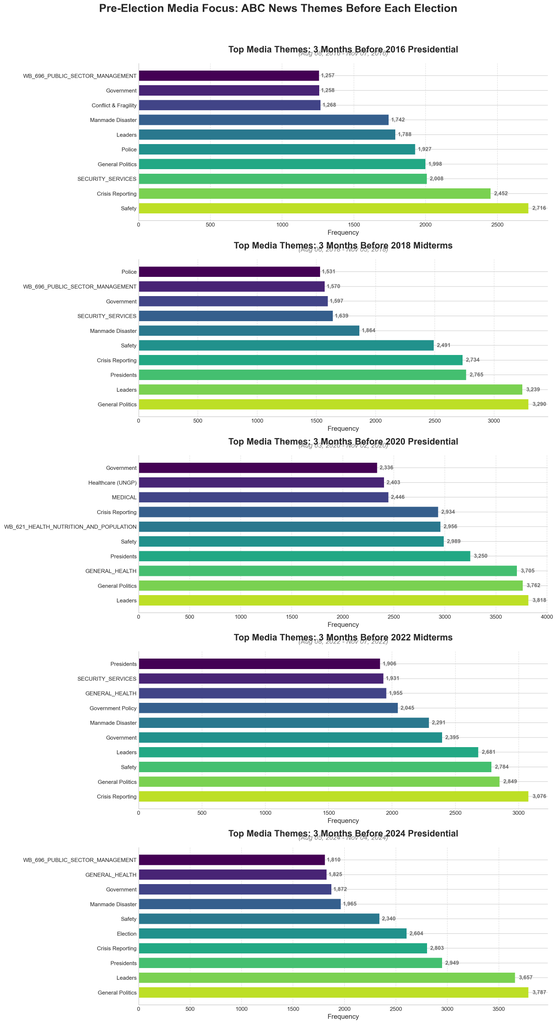

```python
# Create visualization for themes 3 months before each election
# Define a professional color palette
palette = plt.cm.viridis(np.linspace(0, 0.9, 10))

# Create subplot grid with adjusted layout
fig, axes = plt.subplots(len(election_dates), 1, figsize=(14, 5*len(election_dates)))
fig.subplots_adjust(hspace=0.5)

# Handle single-election case
if len(election_dates) == 1:
    axes = [axes]

# For each election, get the most common themes in the 3 months before
for i, (election, date) in enumerate(election_dates.items()):
    pre_start = date - pd.DateOffset(months=3)
    pre_end = date - pd.DateOffset(days=1)

    # Get themes for this time period
    election_window = (df["parsed_date"] >= pre_start) & (df["parsed_date"] <= pre_end)
    pre_election_themes = df.loc[election_window, "V2Themes"].dropna().str.split(";")

    # Extract and count themes
    theme_counts = [theme.split(",")[0] for sublist in pre_election_themes for theme in sublist if theme]
    top_themes = Counter(theme_counts).most_common(10)

    # Map to friendly names
    friendly_themes = [(theme_name_mapping.get(theme, theme), count) for theme, count in top_themes]

    # Create DataFrame for this election
    theme_df = pd.DataFrame(friendly_themes, columns=['Theme', 'Count'])
    theme_df = theme_df.sort_values('Count')

    # Plot horizontal bar chart
    ax = axes[i]
    bars = ax.barh(theme_df['Theme'], theme_df['Count'], color=palette, height=0.7)

    # Add count labels
    for bar in bars:
        width = bar.get_width()
        ax.text(width + (width * 0.01), bar.get_y() + bar.get_height()/2,
                f'{width:,.0f}', ha='left', va='center', fontsize=10,
                fontweight='bold', color='dimgrey')

    # Set titles and labels
    ax.set_title(f"Top Media Themes: 3 Months Before {election}",
                fontsize=16, fontweight='bold', pad=20)
    ax.set_xlabel('Frequency', fontsize=12)
    ax.set_ylabel('')
    ax.invert_yaxis()

    # Improve styling
    ax.grid(axis='x', linestyle='--', alpha=0.7, color='lightgrey')
    ax.spines['right'].set_visible(False)
    ax.spines['top'].set_visible(False)

    # Annotate the date range
    date_range = f"({pre_start.strftime('%b %d, %Y')} - {pre_end.strftime('%b %d, %Y')})"
    ax.text(0.5, 1.05, date_range, transform=ax.transAxes,
            ha='center', fontsize=12, fontstyle='italic', color='grey')

plt.suptitle("Pre-Election Media Focus: ABC News Themes Before Each Election",
             fontsize=20, y=1.02, fontweight='bold')

plt.tight_layout()
plt.show()
```

## 4.3 Post-Election Theme Analysis (3 Months)

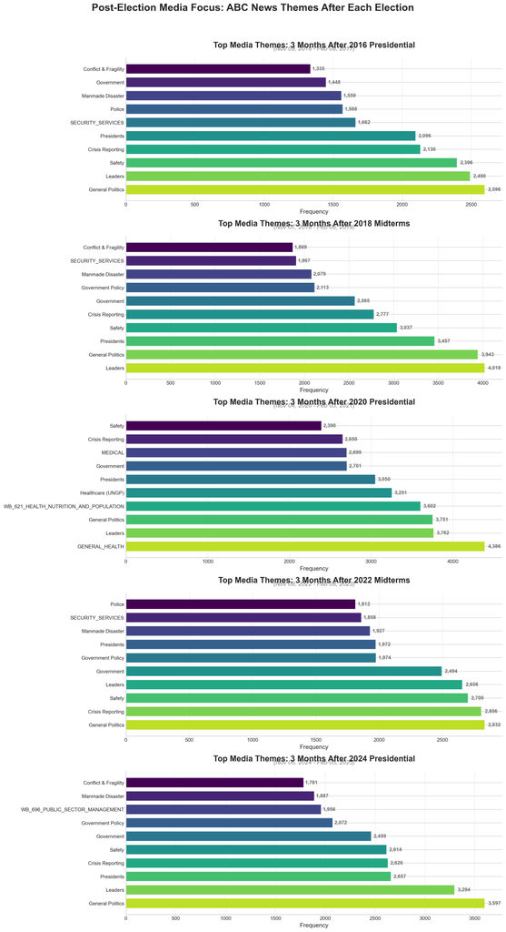

```python
# Create visualization for themes 3 months after each election
fig, axes = plt.subplots(len(election_dates), 1, figsize=(14, 5*len(election_dates)))
fig.subplots_adjust(hspace=0.5)

# Handle single-election case
if len(election_dates) == 1:
    axes = [axes]

# For each election, get the most common themes in the 3 months after
for i, (election, date) in enumerate(election_dates.items()):
    post_start = date + pd.DateOffset(days=1)
    post_end = date + pd.DateOffset(months=3)

    # Get themes for this time period
    election_window = (df["parsed_date"] >= post_start) & (df["parsed_date"] <= post_end)
    post_election_themes = df.loc[election_window, "V2Themes"].dropna().str.split(";")

    # Extract and count themes
    theme_counts = [theme.split(",")[0] for sublist in post_election_themes for theme in sublist if theme]
    top_themes = Counter(theme_counts).most_common(10)

    # Map to friendly names
    friendly_themes = [(theme_name_mapping.get(theme, theme), count) for theme, count in top_themes]

    # Create DataFrame for this election
    theme_df = pd.DataFrame(friendly_themes, columns=['Theme', 'Count'])
    theme_df = theme_df.sort_values('Count')

    # Plot horizontal bar chart
    ax = axes[i]
    bars = ax.barh(theme_df['Theme'], theme_df['Count'], color=palette, height=0.7)

    # Add count labels
    for bar in bars:
        width = bar.get_width()
        ax.text(width + (width * 0.01), bar.get_y() + bar.get_height()/2,
                f'{width:,.0f}', ha='left', va='center', fontsize=10,
                fontweight='bold', color='dimgrey')

    # Set titles and labels
    ax.set_title(f"Top Media Themes: 3 Months After {election}",
                fontsize=16, fontweight='bold', pad=20)
    ax.set_xlabel('Frequency', fontsize=12)
    ax.set_ylabel('')
    ax.invert_yaxis()

    # Improve styling
    ax.grid(axis='x', linestyle='--', alpha=0.7, color='lightgrey')
    ax.spines['right'].set_visible(False)
    ax.spines['top'].set_visible(False)

    # Annotate the date range
    date_range = f"({post_start.strftime('%b %d, %Y')} - {post_end.strftime('%b %d, %Y')})"
    ax.text(0.5, 1.05, date_range, transform=ax.transAxes,
            ha='center', fontsize=12, fontstyle='italic', color='grey')

plt.suptitle("Post-Election Media Focus: ABC News Themes After Each Election",
             fontsize=20, y=1.02, fontweight='bold')

plt.tight_layout()
plt.show()
```

**Post-Election Media Focus**: - The President/Presidential themes often remain dominant immediately after elections - Government administration themes become more prominent in the post-election period - Some campaign-related themes decrease in prominence

## 4.4 Extended Post-Election Coverage (6 Months)

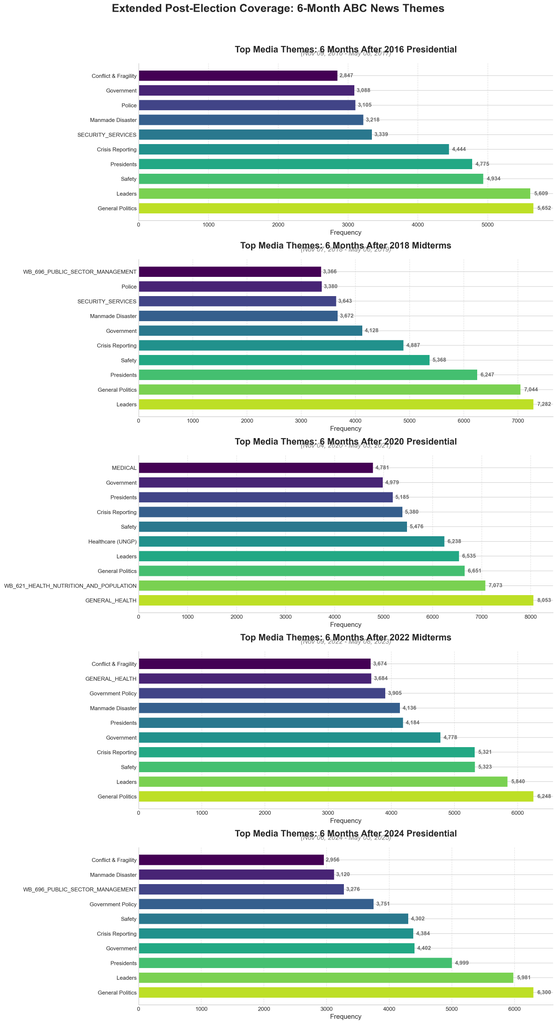

```python
# Create visualization for themes 6 months after each election
fig, axes = plt.subplots(len(election_dates), 1, figsize=(14, 5*len(election_dates)))
fig.subplots_adjust(hspace=0.5)

# Handle single-election case
if len(election_dates) == 1:
    axes = [axes]

# For each election, get the most common themes in the 6 months after
for i, (election, date) in enumerate(election_dates.items()):
    post_start = date + pd.DateOffset(days=1)
    post_end = date + pd.DateOffset(months=6)

    # Get themes for this time period
    election_window = (df["parsed_date"] >= post_start) & (df["parsed_date"] <= post_end)
    post_election_themes = df.loc[election_window, "V2Themes"].dropna().str.split(";")

    # Extract and count themes
    theme_counts = [theme.split(",")[0] for sublist in post_election_themes for theme in sublist if theme]
    top_themes = Counter(theme_counts).most_common(10)

    # Map to friendly names
    friendly_themes = [(theme_name_mapping.get(theme, theme), count) for theme, count in top_themes]

    # Create DataFrame for this election
    theme_df = pd.DataFrame(friendly_themes, columns=['Theme', 'Count'])
    theme_df = theme_df.sort_values('Count')

    # Plot horizontal bar chart
    ax = axes[i]
    bars = ax.barh(theme_df['Theme'], theme_df['Count'], color=palette, height=0.7)

    # Add count labels
    for bar in bars:
        width = bar.get_width()
        ax.text(width + (width * 0.01), bar.get_y() + bar.get_height()/2,
                f'{width:,.0f}', ha='left', va='center', fontsize=10,
                fontweight='bold', color='dimgrey')

    # Set titles and labels
    ax.set_title(f"Top Media Themes: 6 Months After {election}",
                fontsize=16, fontweight='bold', pad=20)
    ax.set_xlabel('Frequency', fontsize=12)
    ax.set_ylabel('')
    ax.invert_yaxis()

    # Improve styling
    ax.grid(axis='x', linestyle='--', alpha=0.7, color='lightgrey')
    ax.spines['right'].set_visible(False)
    ax.spines['top'].set_visible(False)

    # Annotate the date range
    date_range = f"({post_start.strftime('%b %d, %Y')} - {post_end.strftime('%b %d, %Y')})"
    ax.text(0.5, 1.05, date_range, transform=ax.transAxes,
            ha='center', fontsize=12, fontstyle='italic', color='grey')

plt.suptitle("Extended Post-Election Coverage: 6-Month ABC News Themes",
             fontsize=20, y=1.02, fontweight='bold')

plt.tight_layout()
plt.show()
```

**Extended Coverage Patterns**: - Over a 6-month post-election period, coverage shows a broader range of themes - Governance and policy themes become more prominent compared to immediate post-election coverage - Emerging issues often rise in prominence, diluting election-specific themes

## 4.5 Theme Shifts Before vs. After Elections

```python
# Function to get theme counts in a specific date range
def get_theme_counts(start_date, end_date):
    mask = (df["parsed_date"] >= start_date) & (df["parsed_date"] <= end_date)
    themes_series = df.loc[mask, "V2Themes"].dropna().str.split(";")
    all_themes = [theme.split(",")[0] for sublist in themes_series for theme in sublist if theme]
    return Counter(all_themes)

# Analyze themes before and after each election
theme_shift_analysis = {}
theme_shift_data = []  # Create a list to store data for the DataFrame

for election, date in election_dates.items():
    pre_start = date - pd.DateOffset(months=3)
    pre_end = date - pd.DateOffset(days=1)
    post_start = date + pd.DateOffset(days=1)
    post_end = date + pd.DateOffset(months=3)

    pre_counts = get_theme_counts(pre_start, pre_end)
    post_counts = get_theme_counts(post_start, post_end)

    # Calculate the difference in theme frequencies
    theme_diff = {theme: post_counts[theme] - pre_counts.get(theme, 0) for theme in post_counts}

    # Sort themes by the magnitude of change
    sorted_theme_diff = sorted(theme_diff.items(), key=lambda item: abs(item[1]), reverse=True)

    # Store top 10 themes with the most change
    theme_shift_analysis[election] = sorted_theme_diff[:10]

    # Add to the data list for DataFrame
    for theme, shift in sorted_theme_diff[:10]:
        theme_shift_data.append({
            "Election": election,
            "Theme": theme,
            "Tone Shift": shift
        })

# Create theme_df from the collected data
theme_df = pd.DataFrame(theme_shift_data)

# Apply theme name mapping
theme_df["Theme"] = theme_df["Theme"].map(lambda x: theme_name_mapping.get(x, x))
```

### 4.5.1 Direct Theme Comparison Visualizations

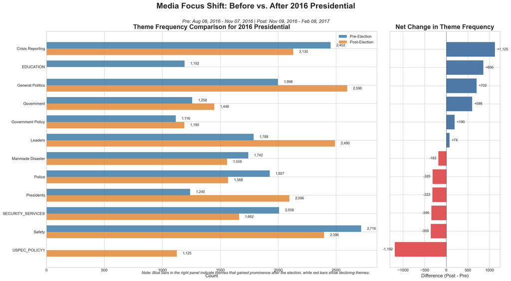

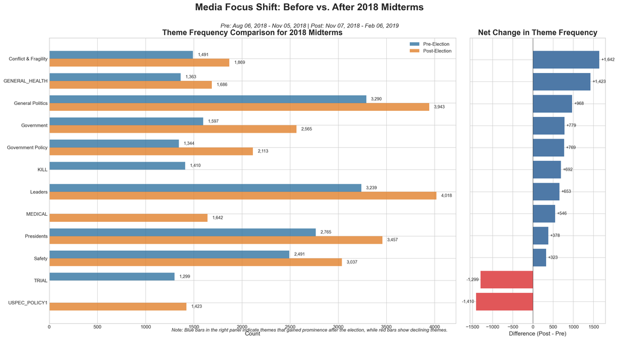

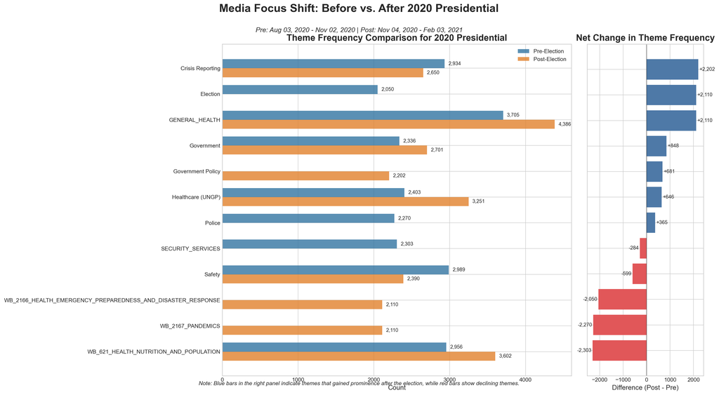

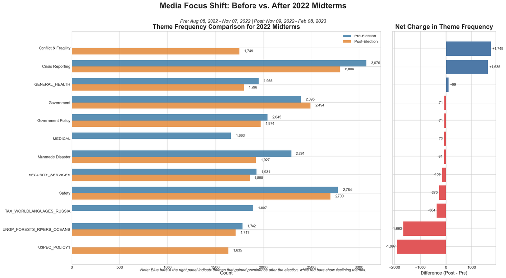

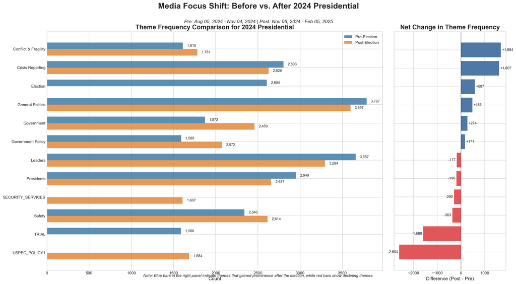

```python
# Create a visualization comparing top themes before and after each election
for election, date in election_dates.items():
    # Define time periods
    pre_start = date - pd.DateOffset(months=3)
    pre_end = date - pd.DateOffset(days=1)
    post_start = date + pd.DateOffset(days=1)
    post_end = date + pd.DateOffset(months=3)

    # Get pre-election themes
    pre_window = (df["parsed_date"] >= pre_start) & (df["parsed_date"] <= pre_end)
    pre_themes = df.loc[pre_window, "V2Themes"].dropna().str.split(";")
    pre_counts = [theme.split(",")[0] for sublist in pre_themes for theme in sublist if theme]
    pre_top = dict(Counter(pre_counts).most_common(15))

    # Get post-election themes
    post_window = (df["parsed_date"] >= post_start) & (df["parsed_date"] <= post_end)
    post_themes = df.loc[post_window, "V2Themes"].dropna().str.split(";")
    post_counts = [theme.split(",")[0] for sublist in post_themes for theme in sublist if theme]
    post_top = dict(Counter(post_counts).most_common(15))

    # Get all unique themes
    all_themes = set(pre_top.keys()) | set(post_top.keys())

    # Create dataframe with both periods
    comparison_data = []
    for theme in all_themes:
        friendly_name = theme_name_mapping.get(theme, theme)
        comparison_data.append({
            'Theme': friendly_name,
            'Pre-Election': pre_top.get(theme, 0),
            'Post-Election': post_top.get(theme, 0),
            'Difference': post_top.get(theme, 0) - pre_top.get(theme, 0)
        })

    # Create DataFrame and sort by absolute difference
    comp_df = pd.DataFrame(comparison_data)
    comp_df = comp_df.sort_values('Difference', key=abs, ascending=False).head(12)

    # Calculate percentages for better comparison
    total_pre = sum(pre_top.values())
    total_post = sum(post_top.values())
    comp_df['Pre %'] = comp_df['Pre-Election'] / total_pre * 100
    comp_df['Post %'] = comp_df['Post-Election'] / total_post * 100
    comp_df['% Change'] = comp_df['Post %'] - comp_df['Pre %']

    # Create figure with multiple subplots
    fig, (ax1, ax2) = plt.subplots(1, 2, figsize=(18, 10), gridspec_kw={'width_ratios': [3, 1]})

    # Plot 1: Side-by-side bar chart of counts
    comp_df = comp_df.sort_values('Theme')  # Sort alphabetically for this chart
    x = np.arange(len(comp_df))
    width = 0.35

    # Plot bars
    pre_bars = ax1.barh(x - width/2, comp_df['Pre-Election'], width,
                      label='Pre-Election', color='#3274A1', alpha=0.8)
    post_bars = ax1.barh(x + width/2, comp_df['Post-Election'], width,
                       label='Post-Election', color='#E1812C', alpha=0.8)

    # Add labels and styling
    ax1.set_yticks(x)
    ax1.set_yticklabels(comp_df['Theme'])
    ax1.invert_yaxis()
    ax1.legend(loc='upper right')
    ax1.set_title(f'Theme Frequency Comparison for {election}', fontsize=16, fontweight='bold')
    ax1.set_xlabel('Count', fontsize=12)

    # Add count labels
    for bars, counts in [(pre_bars, comp_df['Pre-Election']),
                         (post_bars, comp_df['Post-Election'])]:
        for bar, count in zip(bars, counts):
            if count > 0:
                ax1.text(count + 50, bar.get_y() + bar.get_height()/2,
                       f'{count:,.0f}', ha='left', va='center', fontsize=9)

    # Plot 2: Net change (waterfall chart alternative)
    comp_df = comp_df.sort_values('Difference')  # Sort by difference for this chart
    colors = ['#E15759' if x < 0 else '#4E79A7' for x in comp_df['Difference']]

    # Plot the differences
    diff_bars = ax2.barh(comp_df['Theme'], comp_df['Difference'], color=colors)

    # Add a vertical line at zero
    ax2.axvline(x=0, color='black', linestyle='-', alpha=0.3)

    # Add labels
    for bar in diff_bars:
        width = bar.get_width()
        label_x_pos = width + np.sign(width) * 50
        if width > 0:
            ha = 'left'
        else:
            ha = 'right'
        ax2.text(label_x_pos, bar.get_y() + bar.get_height()/2,
                f'{width:+,.0f}', ha=ha, va='center', fontsize=9)

    ax2.set_title('Net Change in Theme Frequency', fontsize=16, fontweight='bold')
    ax2.set_xlabel('Difference (Post - Pre)', fontsize=12)
    ax2.set_yticklabels([])  # Hide y-labels as they're in the first plot

    # Add overall title and subtitles
    plt.suptitle(f'Media Focus Shift: Before vs. After {election}', fontsize=20, fontweight='bold', y=0.98)
    pre_range = f"Pre: {pre_start.strftime('%b %d, %Y')} - {pre_end.strftime('%b %d, %Y')}"
    post_range = f"Post: {post_start.strftime('%b %d, %Y')} - {post_end.strftime('%b %d, %Y')}"
    fig.text(0.5, 0.91, f"{pre_range} | {post_range}", ha='center', fontsize=12, fontstyle='italic')

    # Add explanatory notes
    fig.text(0.5, 0.03,
            "Note: Blue bars in the right panel indicate themes that gained prominence after the election, while red bars show declining themes.",
            ha='center', fontsize=10, fontstyle='italic')

    plt.tight_layout()
    plt.subplots_adjust(top=0.88)
    plt.show()
```

## 4.6 Theme-Specific Tone Analysis

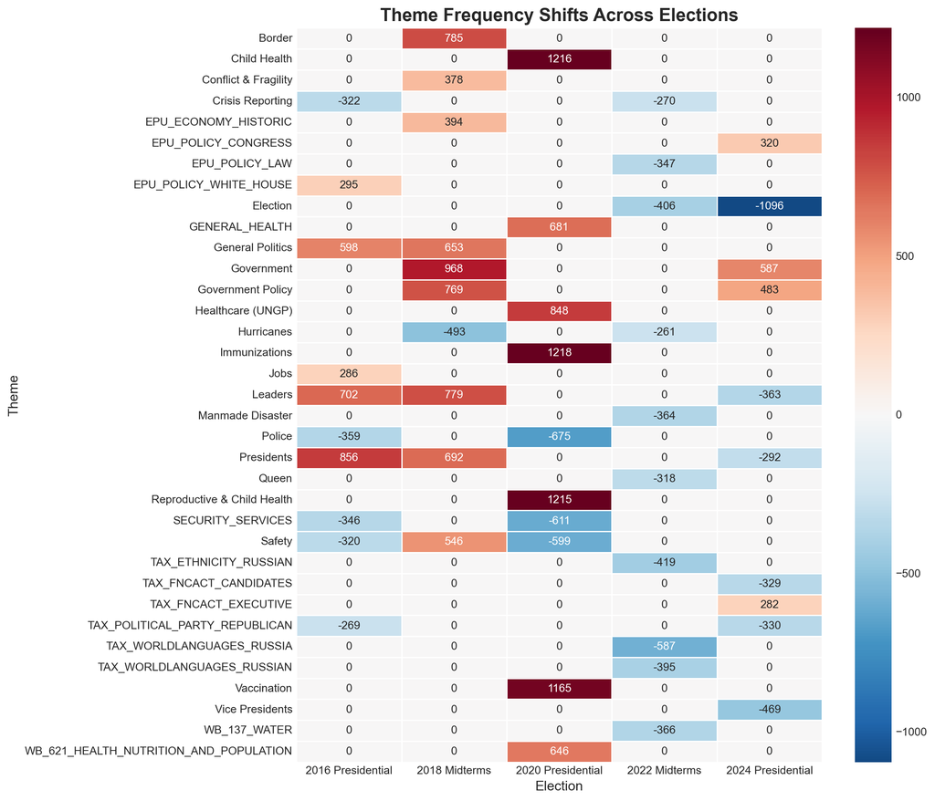

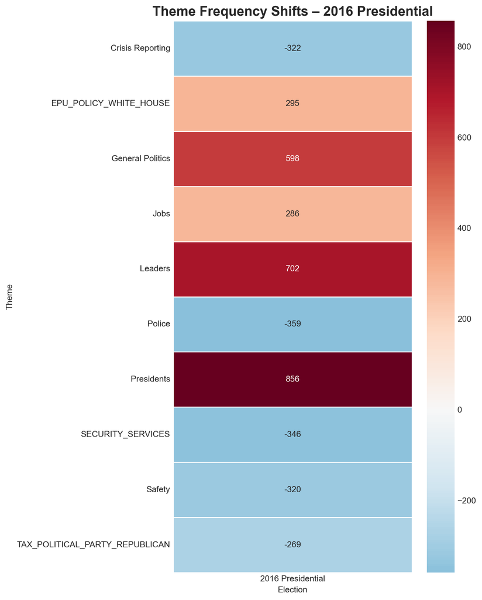

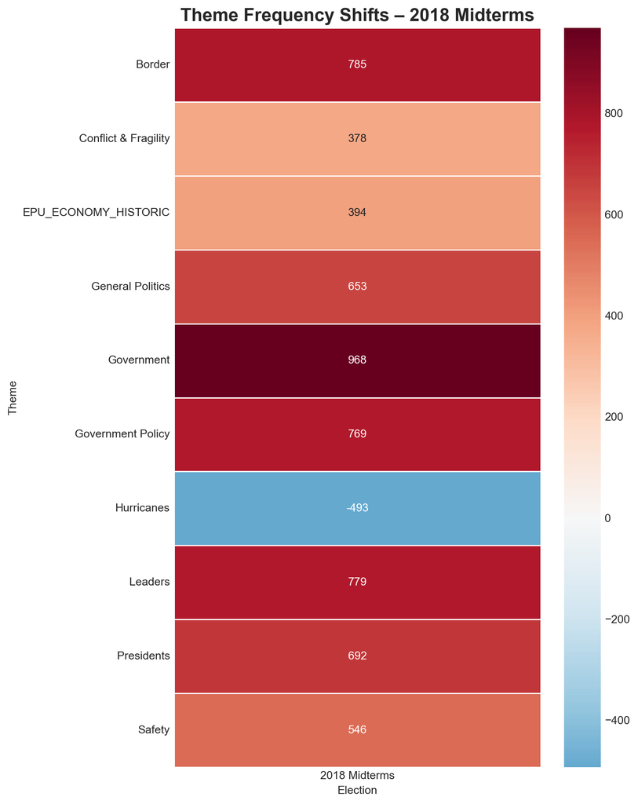

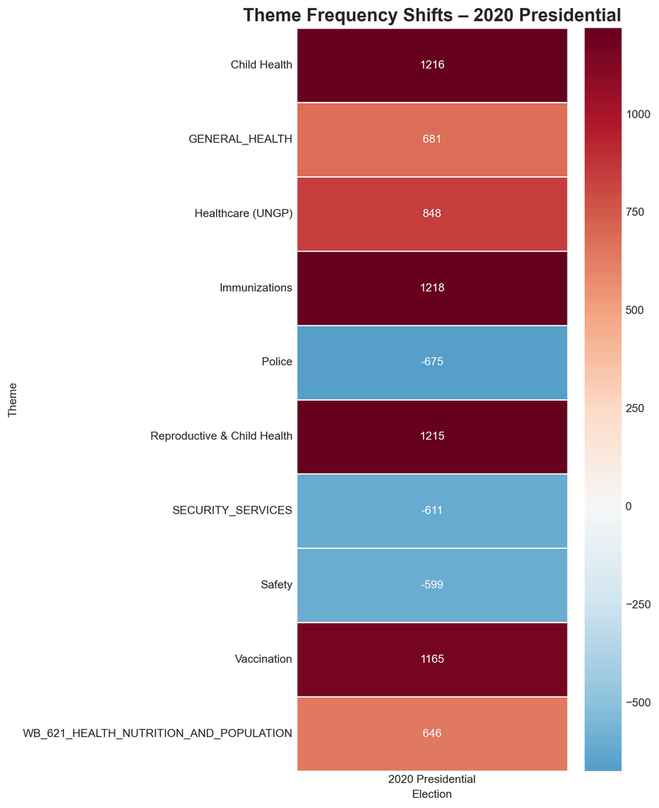

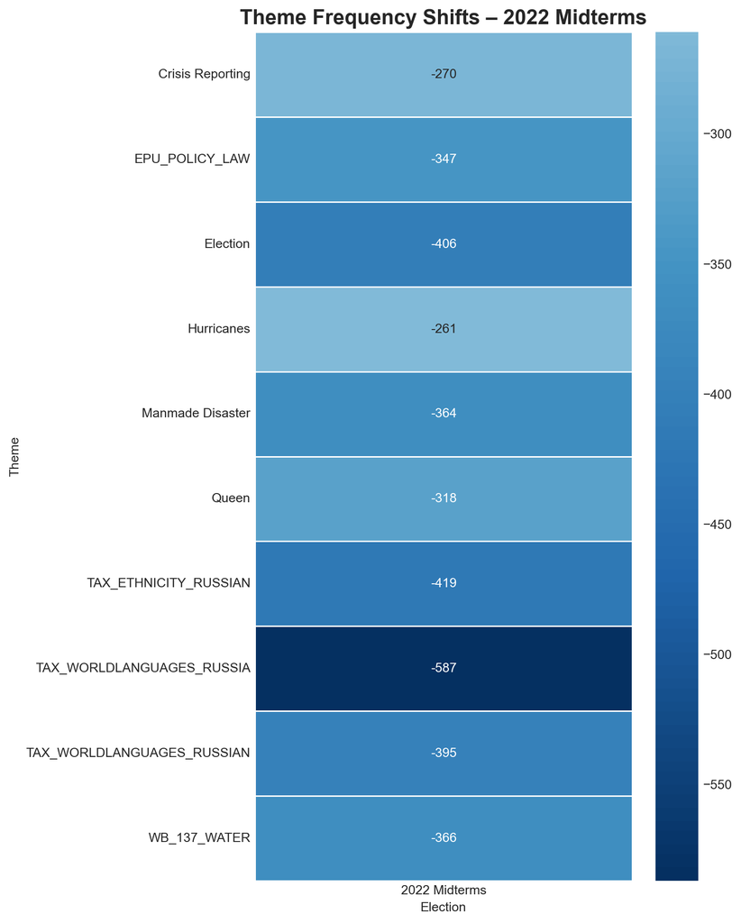

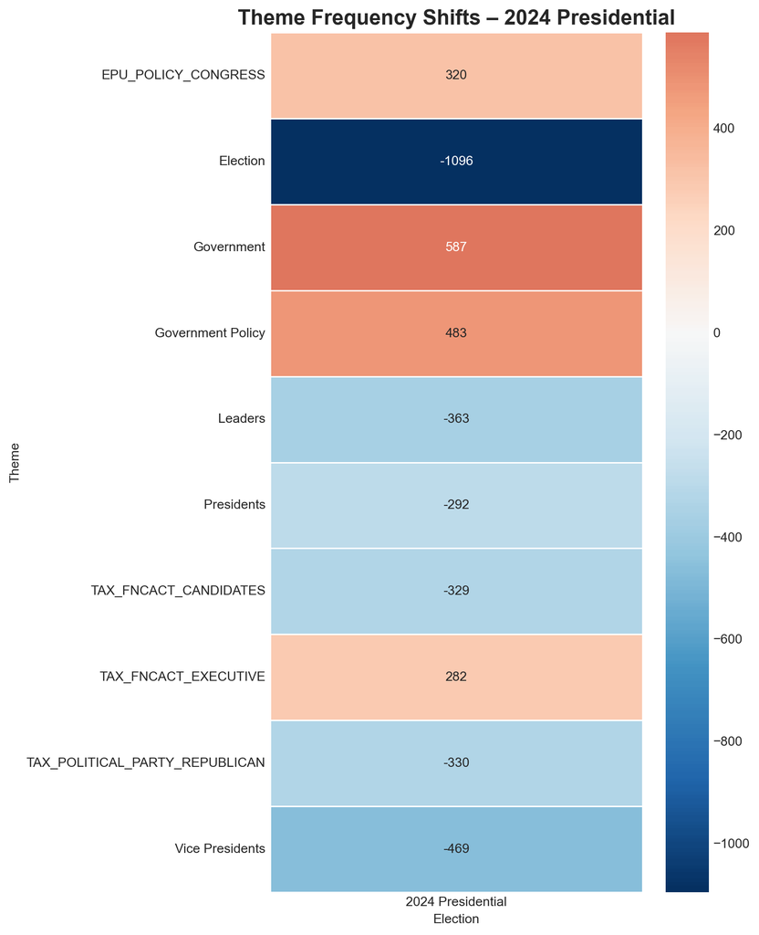

```python
# Create a heatmap visualization of theme tone shifts across elections
# Create pivot table for heatmap
pivot_df = theme_df.pivot(index="Theme", columns="Election", values="Tone Shift").fillna(0)

# Overall heatmap
plt.figure(figsize=(12, 10))
sns.heatmap(pivot_df, cmap="RdBu_r", center=0, annot=True, fmt=".0f", linewidths=0.5)
plt.title("Theme Frequency Shifts Across Elections", fontsize=16, fontweight='bold')
plt.ylabel("Theme", fontsize=12)
plt.xlabel("Election", fontsize=12)
plt.tight_layout()
plt.show()

# Individual election heatmaps for clearer detail
unique_elections = theme_df["Election"].unique()

for election in unique_elections:
    # Filter for this election and create a pivot table
    election_df = theme_df[theme_df["Election"] == election]
    single_df = election_df.pivot(index="Theme", columns="Election", values="Tone Shift").fillna(0)

    plt.figure(figsize=(8, 10))
    sns.heatmap(single_df, cmap="RdBu_r", center=0, annot=True, fmt=".0f", linewidths=0.5)
    plt.title(f"Theme Frequency Shifts – {election}", fontsize=16, fontweight='bold')
    plt.xlabel("Election")
    plt.ylabel("Theme")
    plt.tight_layout()
    plt.show()
```

**Understanding the Heatmap**:

- **Rows (Y-axis)**: Each theme extracted from ABC News coverage
- **Columns (X-axis)**: Different election cycles
- **Colors**:
  - Red = Increased theme frequency after the election
  - Blue = Decreased theme frequency after the election
  - White = No significant change
- **Numbers**: The raw count difference between post-election and pre-election periods

## 4.7 Theme Evolution Timeline

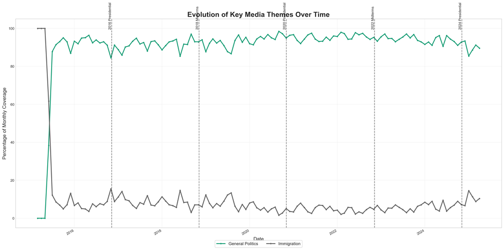

```python
# Create a timeline visualization showing how key themes evolved across all elections

# Select important themes to track over time
key_themes = ['Immigration', 'General Politics']
theme_codes = {v: k for k, v in theme_name_mapping.items() if v in key_themes}
theme_codes.update({k: k for k in key_themes if k not in theme_name_mapping.values()})

# Get monthly data for these themes
monthly_data = []

# Convert min and max years to integers explicitly
min_year = int(df['parsed_date'].dt.year.min())
max_year = int(df['parsed_date'].dt.year.max() + 1)

# Create timeline with monthly data points
for year in range(min_year, max_year):
    for month in range(1, 13):
        start_date = pd.Timestamp(f"{year}-{month:02d}-01")
        if month == 12:
            end_date = pd.Timestamp(f"{year+1}-01-01") - pd.Timedelta(days=1)
        else:
            end_date = pd.Timestamp(f"{year}-{month+1:02d}-01") - pd.Timedelta(days=1)

        # Skip dates outside our dataset
        if start_date < df['parsed_date'].min() or start_date > df['parsed_date'].max():
            continue

        # Get themes for this month
        mask = (df["parsed_date"] >= start_date) & (df["parsed_date"] <= end_date)
        if df.loc[mask].shape[0] == 0:  # Skip months with no data
            continue

        month_themes = df.loc[mask, "V2Themes"].dropna().str.split(";")
        all_month_themes = [theme.split(",")[0] for sublist in month_themes for theme in sublist if theme]
        theme_counter = Counter(all_month_themes)

        # Get counts for our key themes
        for display_name, code in theme_codes.items():
            monthly_data.append({
                'date': start_date,
                'theme': display_name,
                'count': theme_counter.get(code, 0)
            })

# Convert to DataFrame
timeline_df = pd.DataFrame(monthly_data)

# Normalize by total monthly theme counts to get percentage
monthly_totals = timeline_df.groupby('date')['count'].sum().reset_index()
monthly_totals.columns = ['date', 'total']
timeline_df = timeline_df.merge(monthly_totals, on='date')
timeline_df['percentage'] = (timeline_df['count'] / timeline_df['total'] * 100).round(2)

# Plot the theme timeline
plt.figure(figsize=(20, 10))

# Get unique themes and assign colors
unique_themes = timeline_df['theme'].unique()
colors = plt.cm.Dark2(np.linspace(0, 1, len(unique_themes)))
theme_colors = dict(zip(unique_themes, colors))

# Create separate trend line for each theme
for theme in unique_themes:
    theme_data = timeline_df[timeline_df['theme'] == theme]
    plt.plot(theme_data['date'], theme_data['percentage'],
             label=theme, linewidth=2.5, color=theme_colors[theme],
             marker='o', markersize=3)

# First create the plot so the y-axis limits are established
plt.xlabel('Date', fontsize=14)
plt.ylabel('Percentage of Monthly Coverage', fontsize=14)
plt.title('Evolution of Key Media Themes Over Time', fontsize=20, fontweight='bold')
plt.grid(True, alpha=0.3)

# Get y-axis limits *after* the plot is created
y_lim = plt.gca().get_ylim()

# Add election markers with fixed y-position
for election, date in election_dates.items():
    plt.axvline(x=date, color='black', linestyle='--', alpha=0.5)
    # Calculate y position based on current y-axis limits
    y_pos = y_lim[1] * 0.95
    plt.text(date, y_pos, election, rotation=90, ha='right', fontsize=10)

plt.legend(loc='upper center', bbox_to_anchor=(0.5, -0.05), ncol=len(unique_themes), fontsize=12, frameon=True)

# Format x-axis date labels
plt.gcf().autofmt_xdate()
plt.tight_layout()
plt.show()
```

**Longitudinal Theme Analysis**:

This visualization tracks key themes as a percentage of total coverage over time, revealing:

- How media focus evolves before, during, and after election periods
- Seasonal patterns in thematic coverage
- Long-term trends in media priorities
- The relationship between certain themes and specific elections

# 5 Comparative Analysis of Tone Across Media

```python
import pandas as pd
import glob

def load_media_data(media_name):
    csv_files = glob.glob(f"../data/{media_name}/*.csv")
    df = pd.concat([pd.read_csv(file) for file in csv_files], ignore_index=True)
    df['media'] = media_name
    return df

abc_df = load_media_data('abc')
msnbc_df = load_media_data('msnbc')
fox_df = load_media_data('fox')

combined_df = pd.concat([abc_df, msnbc_df, fox_df], ignore_index=True)

tone_split = combined_df["V2Tone"].str.split(",", expand=True)
combined_df["tone"] = pd.to_numeric(tone_split[0], errors="coerce")
combined_df["parsed_date"] = pd.to_datetime(combined_df["parsed_date"], errors="coerce").dt.tz_localize(None)
```

## 5.1 Comparative visualization of cross-media tone

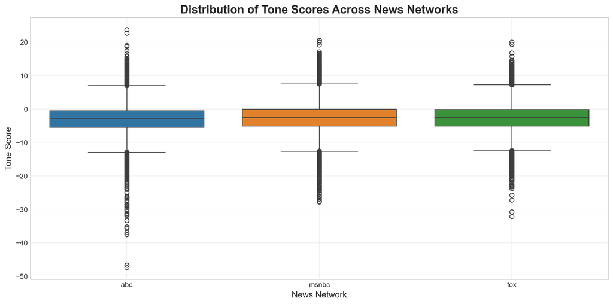

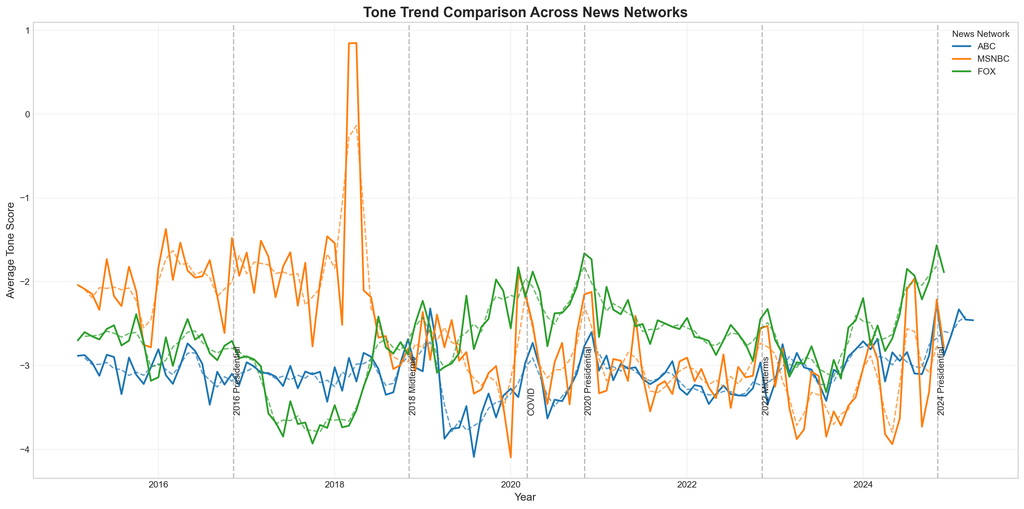

```python
import matplotlib.pyplot as plt
import seaborn as sns

plt.style.use('seaborn-v0_8-whitegrid')
plt.rcParams['font.family'] = 'sans-serif'

plt.figure(figsize=(12, 6))
sns.boxplot(x='media', y='tone', data=combined_df, palette=['#1f77b4', '#ff7f0e', '#2ca02c'])
plt.title('Distribution of Tone Scores Across News Networks', fontsize=16, fontweight='bold')
plt.xlabel('News Network', fontsize=12)
plt.ylabel('Tone Score', fontsize=12)
plt.grid(True, alpha=0.3)
plt.tight_layout()
plt.show()

combined_df['year_month'] = combined_df['parsed_date'].dt.to_period('M')
media_tone_trend = combined_df.groupby(['year_month', 'media'])['tone'].mean().reset_index()
media_tone_trend['year_month'] = pd.to_datetime(media_tone_trend['year_month'].astype(str))

plt.figure(figsize=(16, 8))
for media, color in zip(['abc', 'msnbc', 'fox'], ['#1f77b4', '#ff7f0e', '#2ca02c']):
    media_data = media_tone_trend[media_tone_trend['media'] == media]
    plt.plot(media_data['year_month'], media_data['tone'],
             label=media.upper(), color=color, linewidth=2)

    media_data['rolling'] = media_data['tone'].rolling(window=3, center=True).mean()
    plt.plot(media_data['year_month'], media_data['rolling'],
             color=color, linestyle='--', alpha=0.7)

for label, date in event_dates.items():
    plt.axvline(date, color='gray', linestyle='--', alpha=0.5)
    plt.text(date, media_tone_trend['tone'].min()+0.5, label,
             rotation=90, va='bottom', fontsize=10)

plt.title('Tone Trend Comparison Across News Networks', fontsize=16, fontweight='bold')
plt.xlabel('Year', fontsize=12)
plt.ylabel('Average Tone Score', fontsize=12)
plt.legend(title='News Network')
plt.grid(True, alpha=0.3)
plt.tight_layout()
plt.show()
```

# 6 Analysis of differences in subject coverage

## 6.1 Comparison of cross-media topic distribution

```python
def preprocess_themes(df):
    themes = df['V2Themes'].dropna().str.split(';')
    return [theme.split(',')[0] for sublist in themes for theme in sublist if theme]

media_themes = {}
for media in ['abc', 'msnbc', 'fox']:
    media_df = combined_df[combined_df['media'] == media]
    themes = preprocess_themes(media_df)
    media_themes[media] = Counter(themes).most_common(20)


theme_comparison = []
for media, themes in media_themes.items():
    for theme, count in themes:
        theme_comparison.append({
            'media': media,
            'theme': theme_name_mapping.get(theme, theme),
            'count': count
        })

theme_comparison_df = pd.DataFrame(theme_comparison)

common_themes = set()
for media in ['abc', 'msnbc', 'fox']:
    themes = set([t[0] for t in media_themes[media]])
    if not common_themes:
        common_themes = themes
    else:
        common_themes &= themes

print(f"Top {len(common_themes)} topics focused by 3 medias:")
for theme in common_themes:
    print(f"- {theme_name_mapping.get(theme, theme)}")
```

```
Top 11 topics focused by 3 medias:
- USPEC_POLICY1
- GENERAL_HEALTH
- Government
- Presidents
- TRIAL
- Conflict & Fragility
- Safety
- Crisis Reporting
- WB_696_PUBLIC_SECTOR_MANAGEMENT
- General Politics
- Leaders
```

## 6.2 Topic comparison visualization

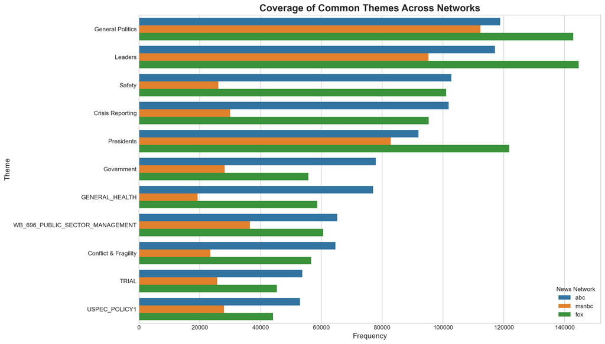

```
ABCUnique topic:
- UNGP_FORESTS_RIVERS_OCEANS
- Government Policy

MSNBCUnique topic:
- EPU_POLICY_POLITICAL
- TAX_ETHNICITY_AMERICAN
- EPU_POLICY_WHITE_HOUSE
- TAX_POLITICAL_PARTY_REPUBLICAN
- TAX_POLITICAL_PARTY_REPUBLICANS
- Election
- Democrats
- LEGISLATION

FOXUnique topic:
- TAX_WORLDMAMMALS_FOX
```

```python
common_theme_counts = theme_comparison_df[theme_comparison_df['theme'].isin(
    [theme_name_mapping.get(t, t) for t in common_themes])]

plt.figure(figsize=(14, 8))
sns.barplot(x='count', y='theme', hue='media', data=common_theme_counts,
            palette=['#1f77b4', '#ff7f0e', '#2ca02c'])
plt.title('Coverage of Common Themes Across Networks', fontsize=16, fontweight='bold')
plt.xlabel('Frequency', fontsize=12)
plt.ylabel('Theme', fontsize=12)
plt.legend(title='News Network')
plt.tight_layout()
plt.show()

unique_themes = {}
for media in ['abc', 'msnbc', 'fox']:
    other_media = set(['abc', 'msnbc', 'fox']) - {media}
    media_themes_set = set([t[0] for t in media_themes[media]])
    for other in other_media:
        media_themes_set -= set([t[0] for t in media_themes[other]])
    unique_themes[media] = media_themes_set

for media, themes in unique_themes.items():
    if themes:
        print(f"\n{media.upper()}Unique topic:")
        for theme in themes:
            print(f"- {theme_name_mapping.get(theme, theme)}")
    else:
        print(f"\n{media.upper()}Has no unique topic")
```

# 7 Differences in media behavior during election cycles

## 7.1 Comparison of changes in tone before and after the election

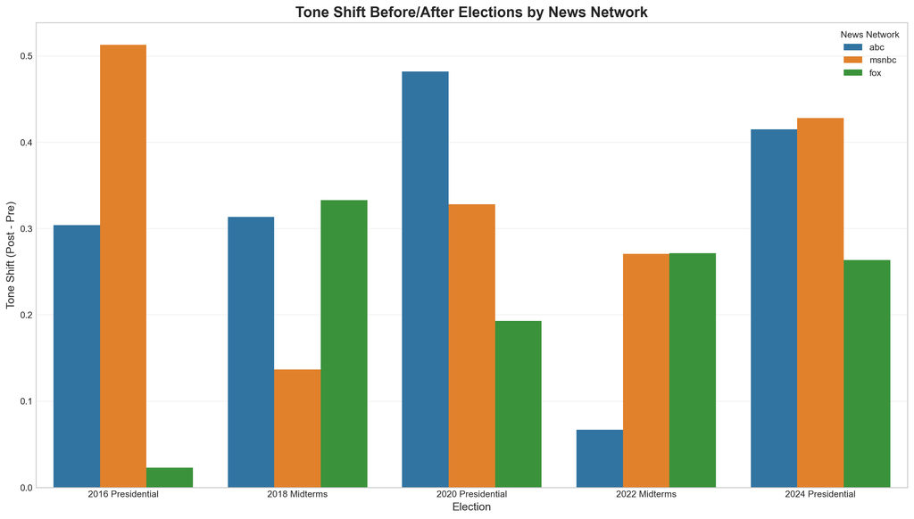

```python
election_shift_results = []
for media in ['abc', 'msnbc', 'fox']:
    media_df = combined_df[combined_df['media'] == media]
    for label, date in election_dates.items():
        pre = media_df[(media_df['parsed_date'] >= date - pd.DateOffset(months=3)) &
                      (media_df['parsed_date'] < date)]
        post = media_df[(media_df['parsed_date'] >= date) &
                       (media_df['parsed_date'] < date + pd.DateOffset(months=3))]

        election_shift_results.append({
            'media': media,
            'election': label,
            'pre_avg_tone': pre['tone'].mean(),
            'post_avg_tone': post['tone'].mean(),
            'tone_shift': post['tone'].mean() - pre['tone'].mean(),
            'pre_articles': len(pre),
            'post_articles': len(post)
        })

election_shift_df = pd.DataFrame(election_shift_results)

plt.figure(figsize=(14, 8))
sns.barplot(x='election', y='tone_shift', hue='media', data=election_shift_df,
            palette=['#1f77b4', '#ff7f0e', '#2ca02c'])
plt.axhline(0, color='black', linewidth=0.5)
plt.title('Tone Shift Before/After Elections by News Network', fontsize=16, fontweight='bold')
plt.xlabel('Election', fontsize=12)
plt.ylabel('Tone Shift (Post - Pre)', fontsize=12)
plt.legend(title='News Network')
plt.grid(axis='y', alpha=0.3)
plt.tight_layout()
plt.show()
```

## 7.2 Differences in topic preferences in election coverage

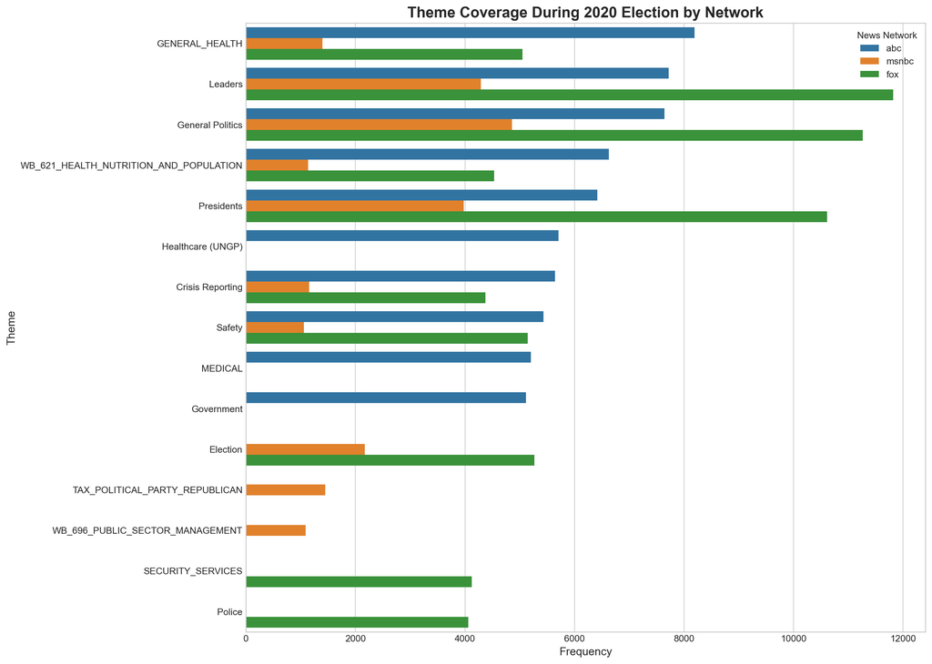

```python
election_theme_results = []
for media in ['abc', 'msnbc', 'fox']:
    media_df = combined_df[combined_df['media'] == media]
    for label, date in election_dates.items():
        period_df = media_df[(media_df['parsed_date'] >= date - pd.DateOffset(months=3)) &
                           (media_df['parsed_date'] <= date + pd.DateOffset(months=3))]
        themes = preprocess_themes(period_df)
        for theme, count in Counter(themes).most_common(10):
            election_theme_results.append({
                'media': media,
                'election': label,
                'theme': theme_name_mapping.get(theme, theme),
                'count': count
            })

election_theme_df = pd.DataFrame(election_theme_results)

election_2020 = election_theme_df[election_theme_df['election'] == '2020 Presidential']

plt.figure(figsize=(14, 10))
sns.barplot(x='count', y='theme', hue='media', data=election_2020,
            palette=['#1f77b4', '#ff7f0e', '#2ca02c'])
plt.title('Theme Coverage During 2020 Election by Network', fontsize=16, fontweight='bold')
plt.xlabel('Frequency', fontsize=12)
plt.ylabel('Theme', fontsize=12)
plt.legend(title='News Network')
plt.tight_layout()
plt.show()
```

# 8 Advanced EDA Analysis

## 8.1 Time series decomposition analysis

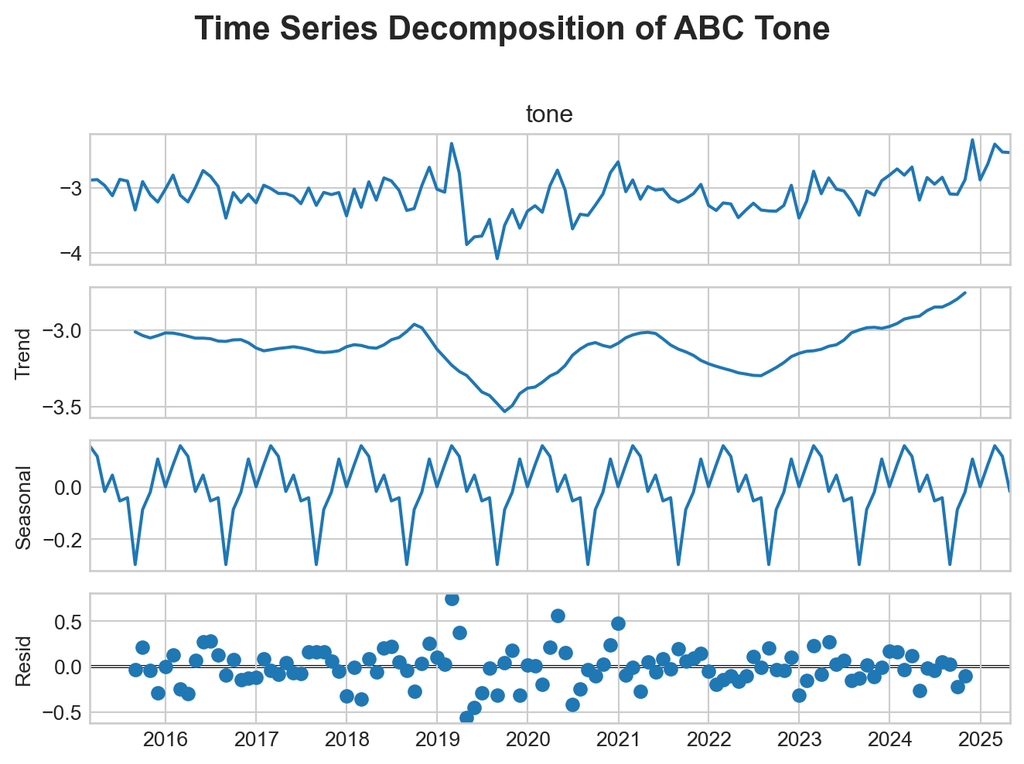

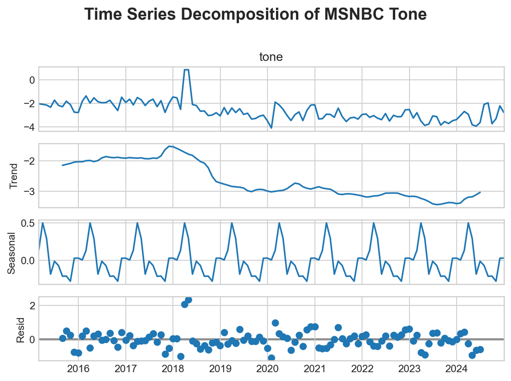

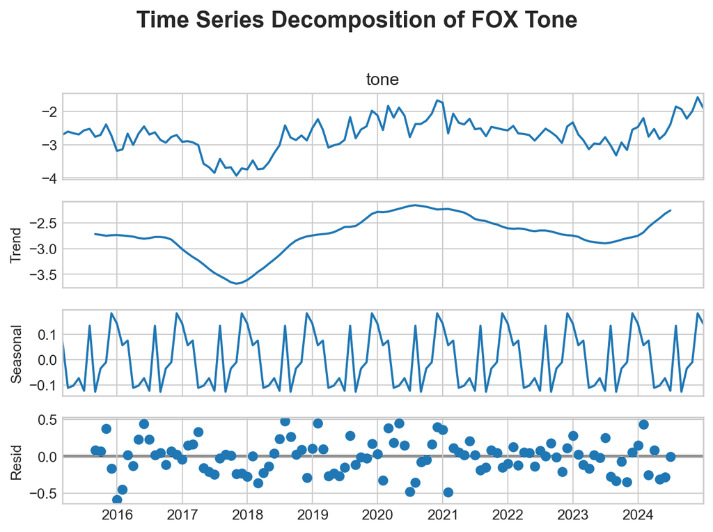

```python
from statsmodels.tsa.seasonal import seasonal_decompose

for media in ['abc', 'msnbc', 'fox']:
    media_tone = combined_df[combined_df['media'] == media].set_index('parsed_date')['tone']
    monthly_tone = media_tone.resample('M').mean().dropna()

    # seasonal
    decomposition = seasonal_decompose(monthly_tone, model='additive', period=12)  # annual seasonal

    plt.figure(figsize=(14, 10))
    decomposition.plot()
    plt.suptitle(f'Time Series Decomposition of {media.upper()} Tone', y=1.02, fontsize=16, fontweight='bold')
    plt.tight_layout()
    plt.show()
```